# Baltimore Community Data Science Collaboration, ToolBank Community and Economic Impact Survey Analysis

# Section 3: General Attitudes Stratified by Respondent and Community Based Organization (CBO) Characteristics

### General Attitudes Stratified by Respondent Years with the CBO

The following plots analyze the questions from section two, stratified by the number of years that the respondent reported working at the CBO. These plots explore if there is a relationship between respondents’ self-reported number of years with the CBO and their attitudes towards the ToolBank’s economic and community impact.

**Figure 2: Respondent Agreement that the ToolBank Reduced Their CBOs Costs Related to Purchasing and Renting Tools and Equipment, Stratified by Respondent Years with the CBO**

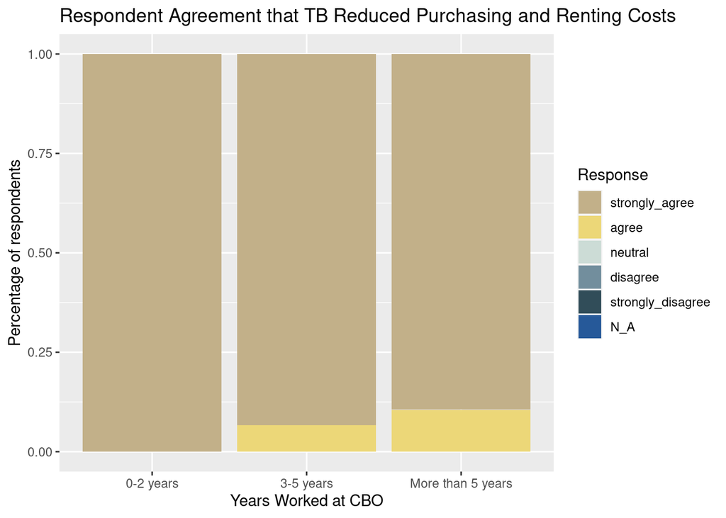

**Figure 3: Respondent Agreement that the ToolBank Reduced Their CBOs Costs Related Storing Tools and Equipment, Stratified by Respondent Years with the CBO**

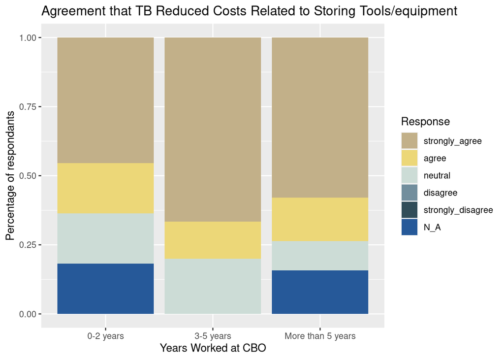

**Figure 4: Respondent Agreement that the ToolBank Reduced Their CBOs Costs Related to Staff Time to Complete Community Projects, Stratified by Respondent Years with the CBO**

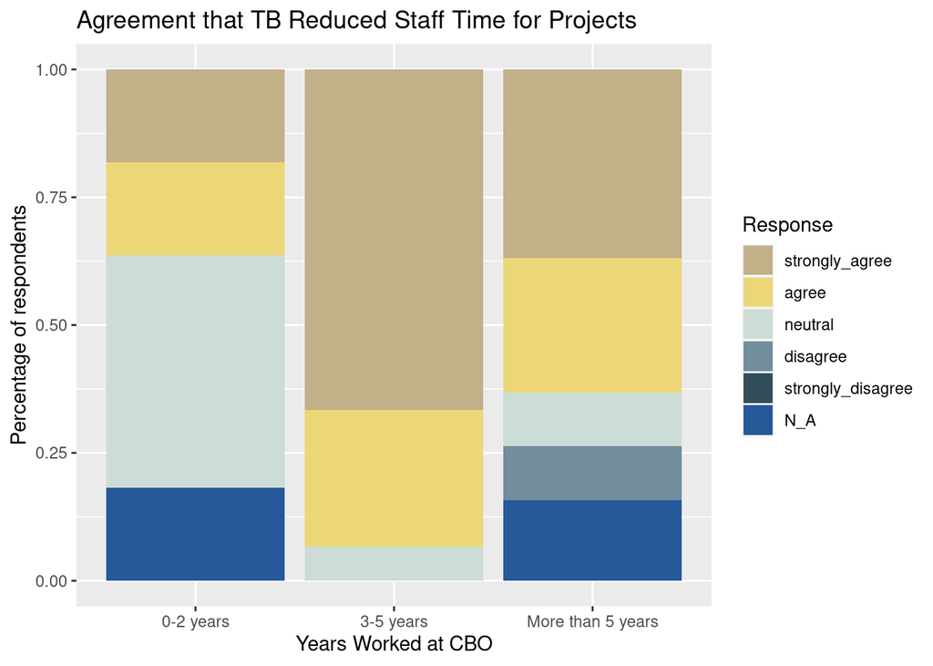

**Figure 5: Respondent Agreement that the ToolBank Has Positively Impacted Their CBO, Stratified by Respondent Years with the CBO**

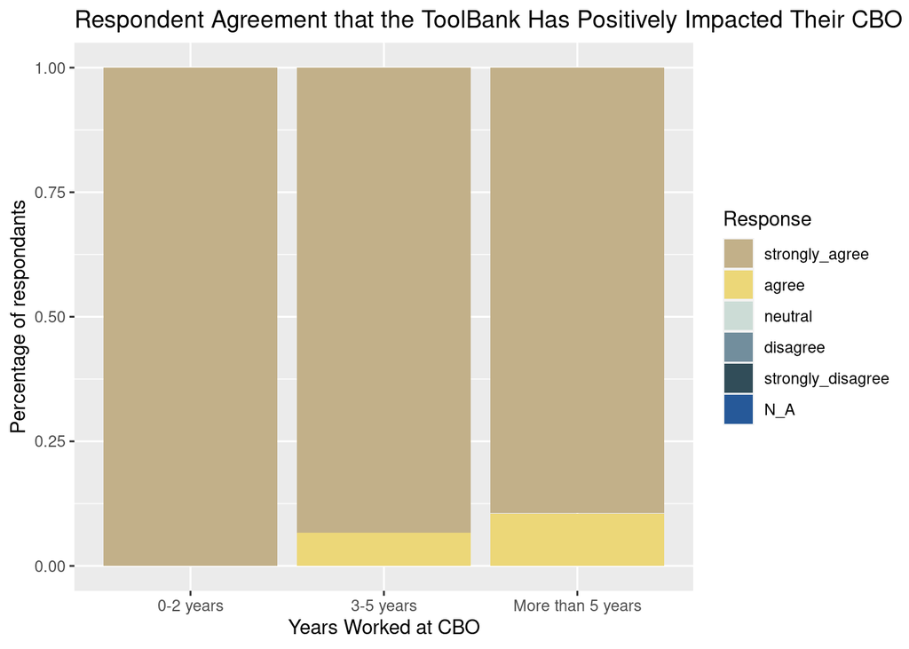

### General Attitudes Stratified by Size of CBO

The following plots analyze the general attitude questions from section two, stratified by the size of the organization, as determined by their publicly available gross receipts. These plots explore if there is a relationship between the size of the funding available to the CBO and the respondents’ attitudes towards the ToolBank’s economic and community impact.

| Table 2a: Number and Percentage of CBOs by 3 Size Categories | Table 2a: Number and Percentage of CBOs by 3 Size Categories Number Respondents | Table 2a: Number and Percentage of CBOs by 3 Size Categories Percent of Total Respondents |
| --- | --- | --- |
| CBO Size |  |  |
| Less than 500k (group 1) | 29 | 64.4% |
| Between 500k and 1000k (group 2) | 3 | 6.7% |
| Greater than 1000k (group 3) | 13 | 28.9% |
| NA | 0 | 0% |

| Table 2b: Number and Percentage of CBOs by 2 Size Categories | Table 2b: Number and Percentage of CBOs by 2 Size Categories Number Respondents | Table 2b: Number and Percentage of CBOs by 2 Size Categories Percent of Total Respondents |
| --- | --- | --- |
| CBO Size |  |  |
| Less than 500k | 29 | 64.4% |
| Greater than 500k | 16 | 35.6% |

**Figure 6: Respondent Agreement that the ToolBank Reduced Their CBO’s Purchasing and Renting Costs, Stratified by CBO Size**

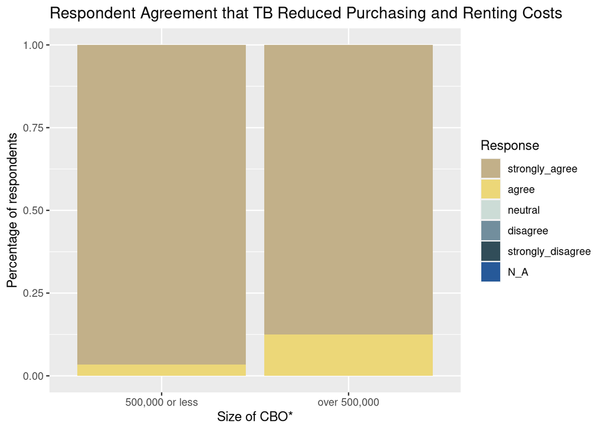

**Figure 7: Respondent Agreement that the ToolBank Reduced Their CBOs Costs Related Storing Tools and Equipment, Stratified by, Stratified by CBO Size**

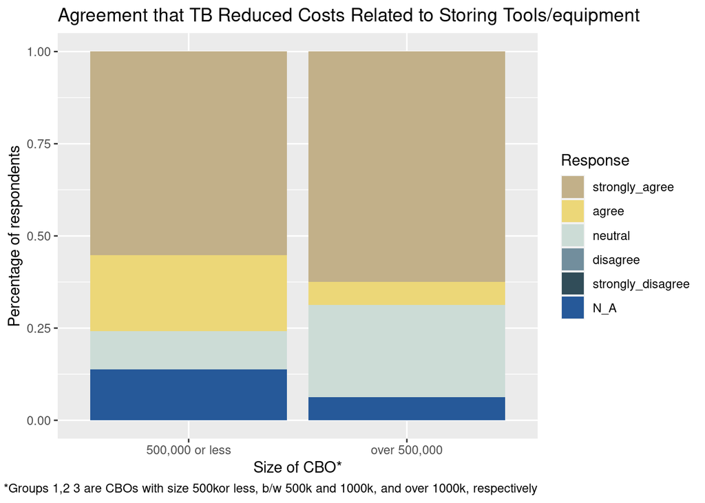

**Figure 8: Respondent Agreement that the ToolBank Reduced Their CBOs Costs Related to Staff Time to Complete Community Projects, Stratified by CBO Size**

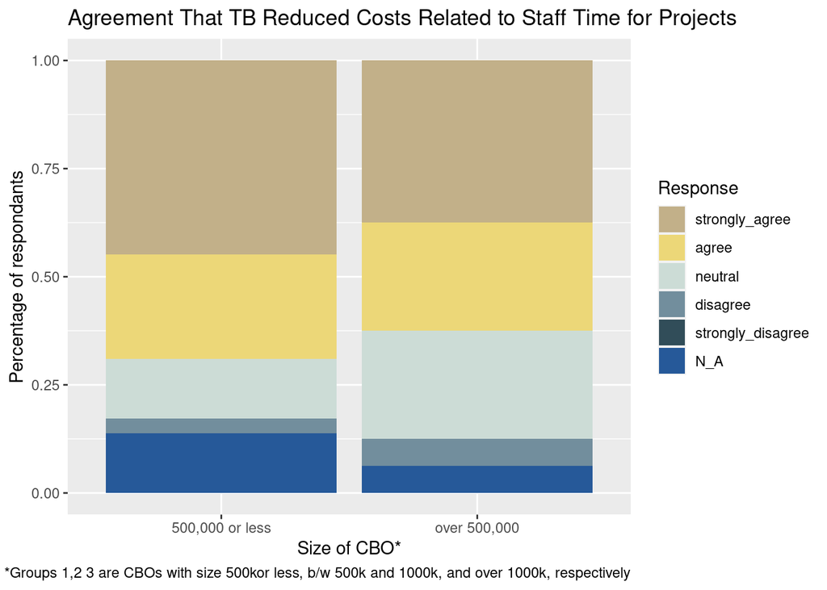

**Figure 9: Respondent Agreement that the ToolBank Has Positively Impacted Their CBO, Stratified by CBO Size**

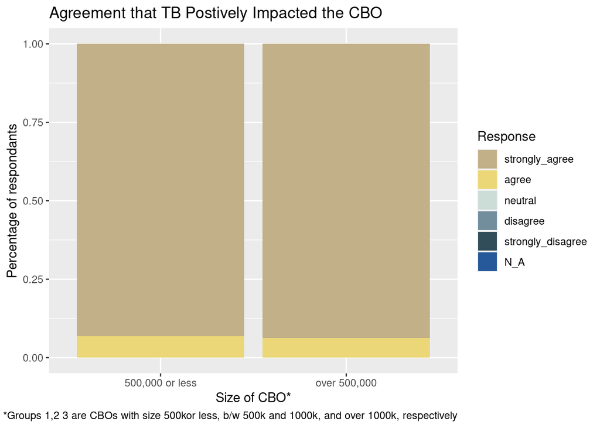

**Findings:**

- In general, larger and smaller CBOs show similar trends in agreement with benefits from the Toolbank. However, smaller CBOs tend to report slightly stronger levels of agreement

### General Attitudes Stratified Minority Status

| Table 3: Number, percentages of respondants indicating minority leadership | Table 3: Number, percentages of respondants indicating minority leadership # Yes (% Yes) | Table 3: Number, percentages of respondants indicating minority leadership # No (% No) |
| --- | --- | --- |
| Minority Leadership |  |  |
| Our top executive position is held by a minority | 25 (56%) | 20 (44%) |
| More than 50% of our board is made up of minorities | 19 (42%) | 26 (58%) |
| More than 50% of program recipients are minorities | 26 (58%) | 19 (42%) |
| None of the above | 5 (11%) | 40 (89%) |

**Figure 10: General Attitudes Toward ToolBank Impact Among Respondents Reporting a Top Executive with Minority Status**

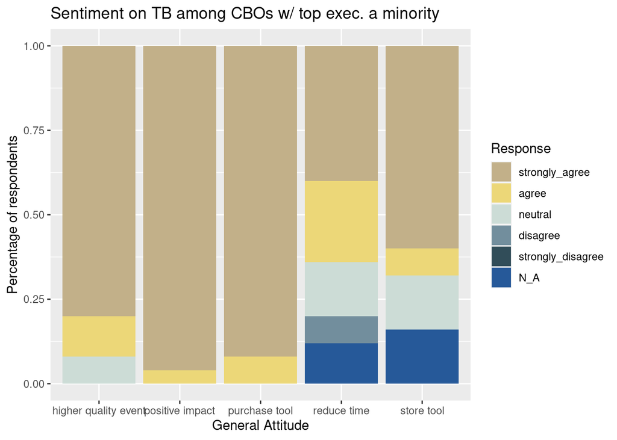

**Figure 11: General Attitudes Toward ToolBank Impact Among Respondents Indicating More Than 50% of Program Recipients as Minorities**

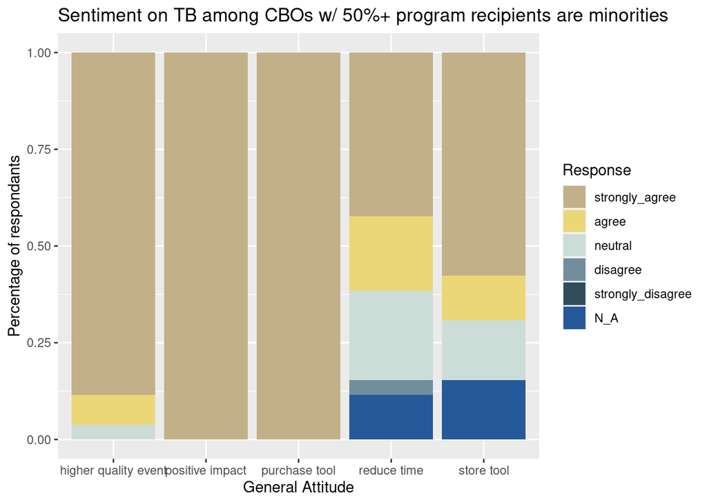

**Figure 12: General Attitudes Toward ToolBank Impact Among Respondents Indicating More Than 50% of CBO Board Members are Minorities**

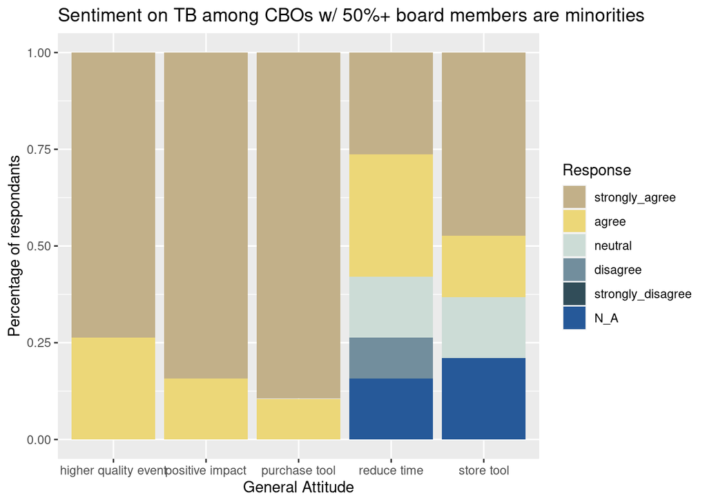

**Figure 13: General Attitudes Toward ToolBank Impact Among Respondents Indicating Their CBO Did Not Meet Any of the Minority Status Criteria Provided**

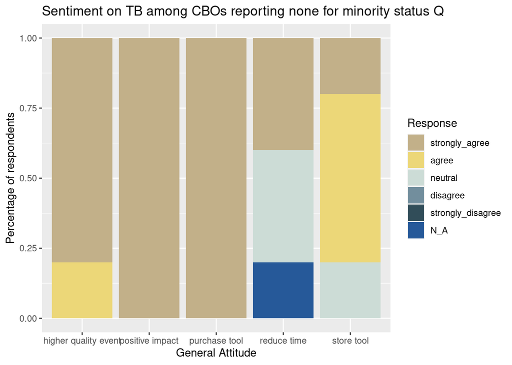

**Findings:**

- Respondents’ attitude towards the TB are similar across organizations with different minority status. Part of the reason may be that respondents in these categories overlap with each other
- Attitudes of respondents from organizations with no minority status are more fluctuated, which is likely related to the small sample size for that group

# Section 4: Economic Benefit of the ToolBank

The following section analyses responses to the survey questions regarding the economic benefit of the ToolBank. For these questions, respondents were asked to provide their best estimates rounded to the nearest dollar. This section aimed to quantify the direct impact of the ToolBank on the member CBOs’ budgets and fundraising capabilities. This section asked respondents the following questions:

- If the TB did not exist, how much would you spend purchasing or renting tools and equipment in an average year?
- If the TB did not exist, how much would you spend on storage of tools and equipment in an average year?
- If the TB did not exist, how much would you spend maintaining tools and equipment in an average year?
- Reflecting on your events in the past year: If the TB did not exist, how much funding would your organization allocate to buying, storing, tracking and maintaining your own inventory of tools and equipment?
- In the past year, how many community events did your organization host?
- If there were no TB, how many of your events in the past year would you not have hosted for any reason?
- If there were no TB, how many of your constituents, including volunteers, members, and event attendees, would have been negatively impacted in the past year?

*Note that the responses to all of the following questions in this section are highly skewed. As a result, we recommended reporting sum, medians, or quantiles rather than averages*

**Figure 14: Distribution of money spent purchasing/renting tools/equipment if TB did not exist**

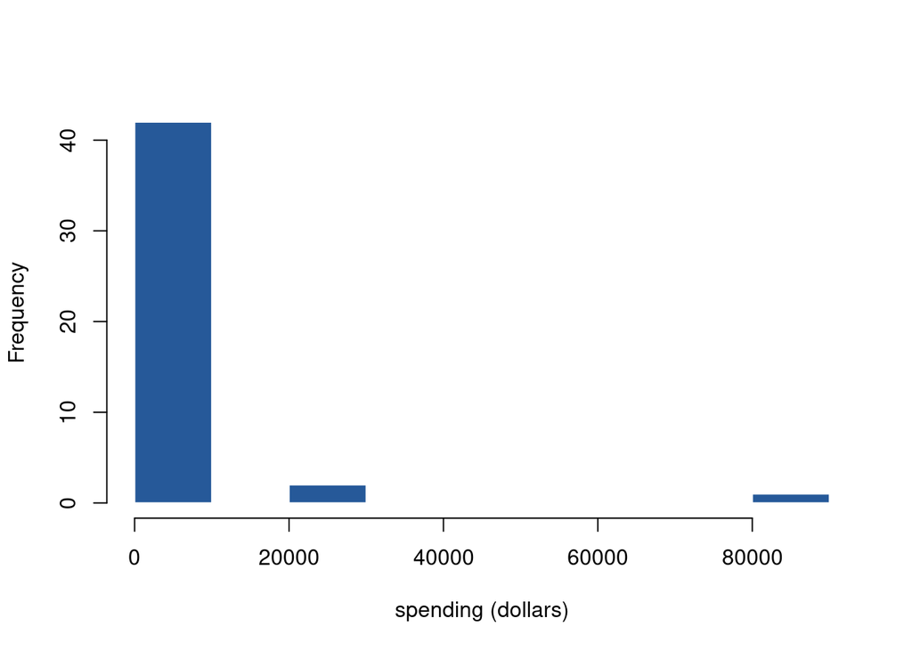

**Figure 15: Distribution of money spent storing tools/equipment if TB did not exist**

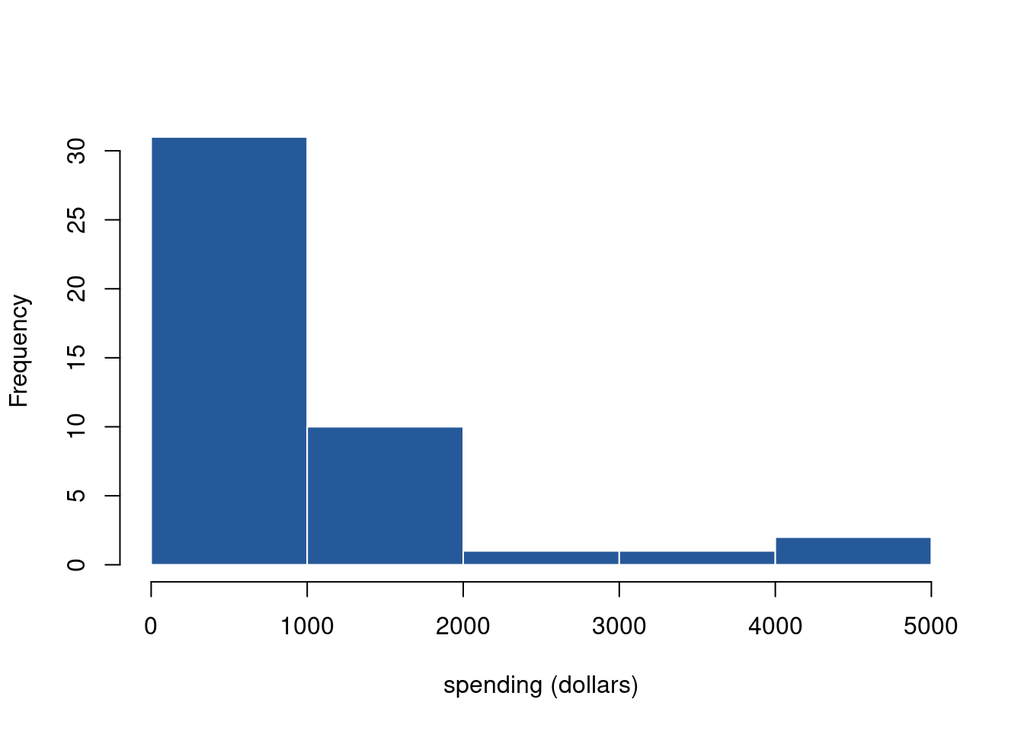

**Figure 16: Distribution of money spent on tool maintenance if TB did not exist**

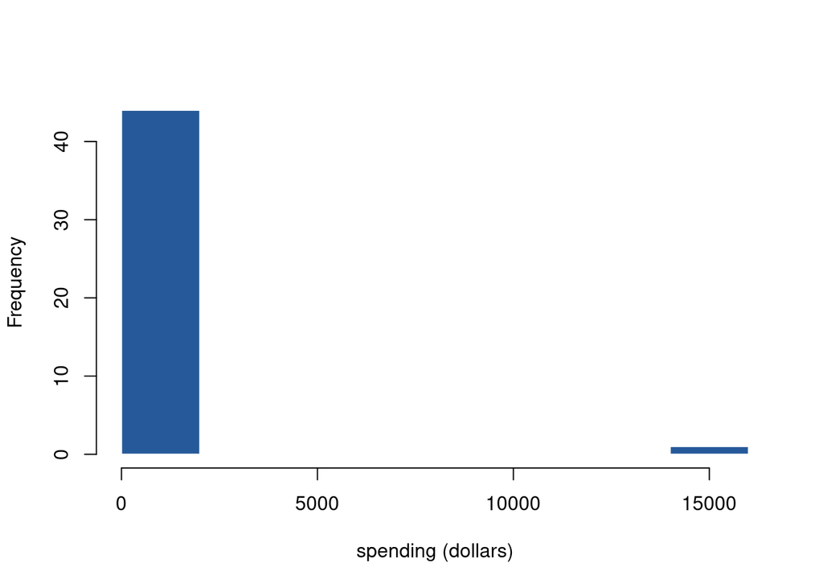

**Figure 17: Dist of money spent on all tool/equipment related costs if TB did not exist (past year)**

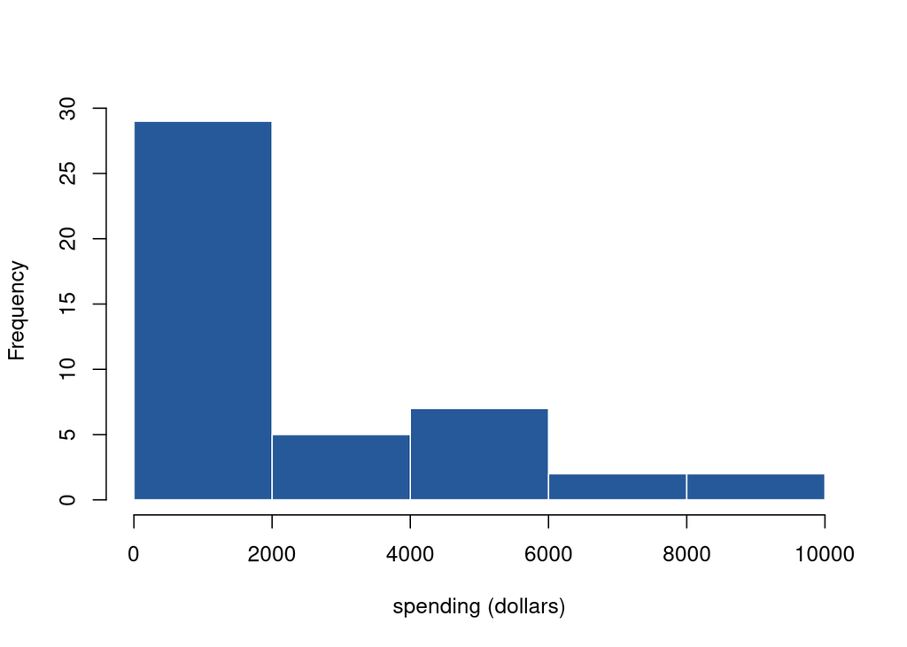

**Figure 18: Distribution of total events hosted in past year**

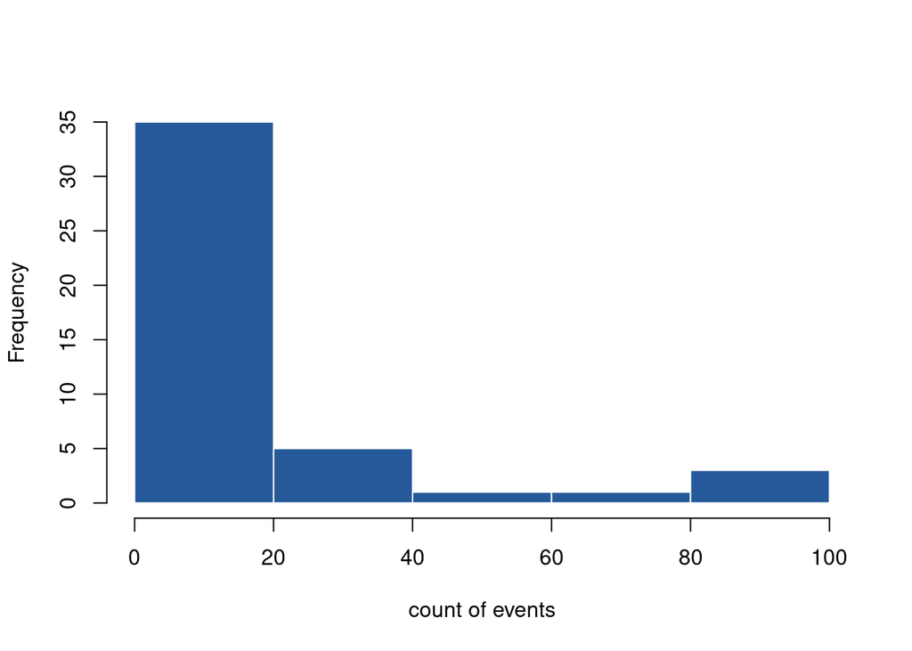

**Figure 19: Distribution of past-year events impossible w/o TB**

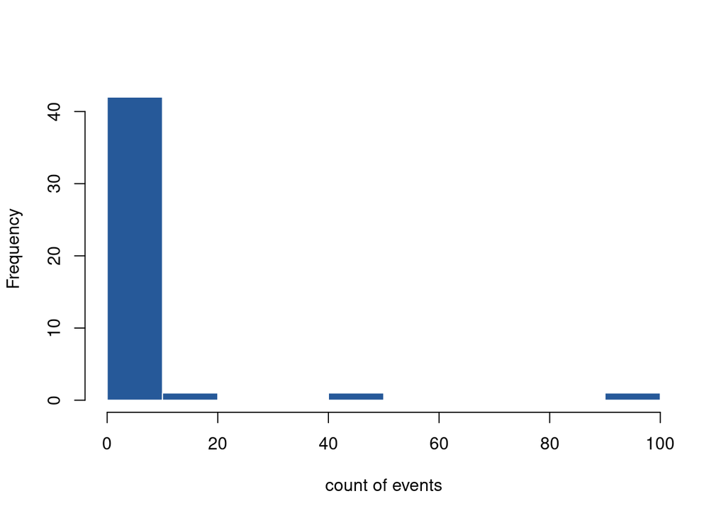

**Figure 20: Distribution of % of past-year events impossible w/o TB**

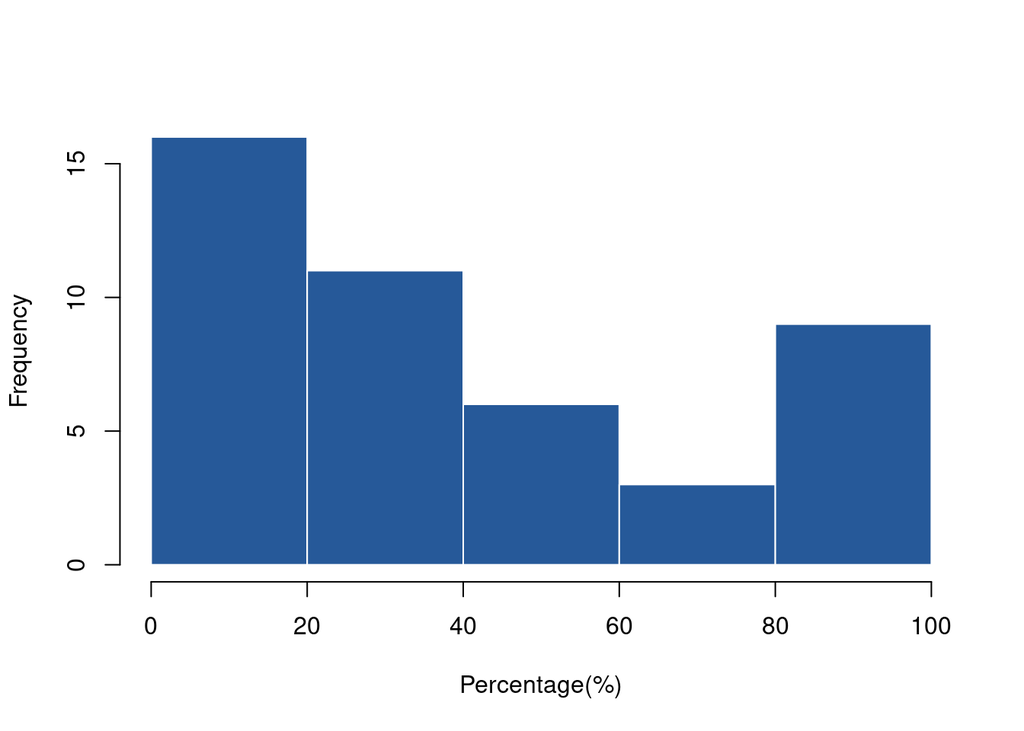

**Figure 21: Distribution of negatively impacted constituents if TB did not exist (past year)**

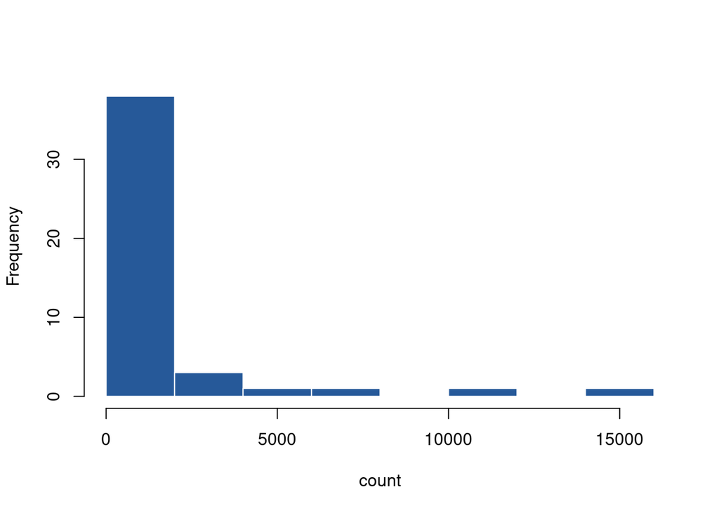

| Table 4: Impact on CBO if TB did not exists | Table 4: Impact on CBO if TB did not exists Mean | Table 4: Impact on CBO if TB did not exists 25th quantile | Table 4: Impact on CBO if TB did not exists Median | Table 4: Impact on CBO if TB did not exists Mode | Table 4: Impact on CBO if TB did not exists 75th quantile | Table 4: Impact on CBO if TB did not exists Standard deviation | Table 4: Impact on CBO if TB did not exists Sum |
| --- | --- | --- | --- | --- | --- | --- | --- |
| Money That Would Have Been Spent if TB Did Not Exist* |  |  |  |  |  |  |  |
| on Purchasing or renting tools and equipment | 5029 | 500 | 2000 | 2000 | 3500 | 14109 | 226300 |
| on storage of tools and equipment | 926 | 0 | 500 | 0 | 1200 | 1196 | 41650 |
| on maintenance of tools and equipment | 817 | 80 | 300 | 500 | 500 | 2227 | 36750 |
| on buying, storing, tracking and maintaining own tool+equiptment inventory | 2527 | 800 | 1500 | 5000 | 3000 | 2532 | 113720 |
| # Events/People Impacted If TB Did Not Exist |  |  |  |  |  |  |  |
| # events that would have been impossible in past year | 6 | 1 | 2 | 0 | 5 | 16 | 280 |
| % of CBO’s total events that would have been impossible in past year | 41 | 4 | 35 | 0 | 62 | 36 | 1826 |
| # constituents that would have been negatively impacted in the past year | 1306 | 75 | 150 | 100 | 500 | 3078 | 58790 |

*in US dollars

**Figures 22a-d: Distribution of events possible through TB by minority status**

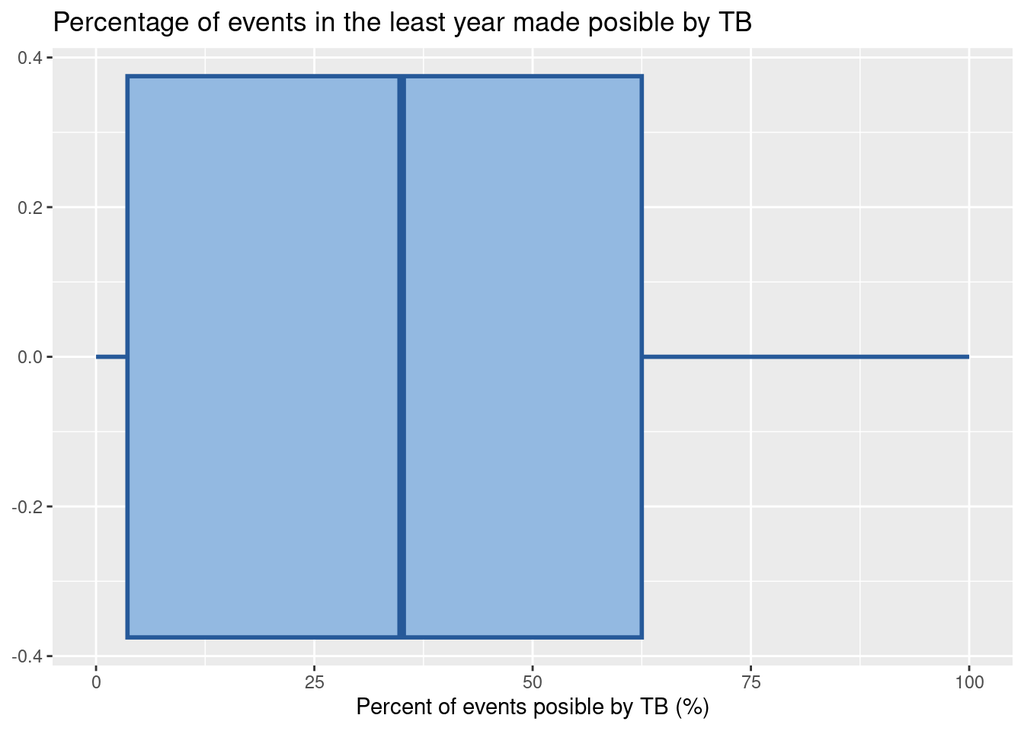

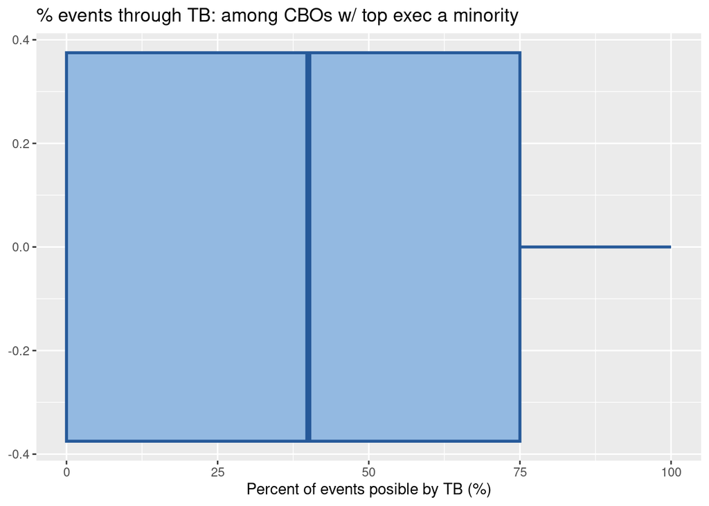

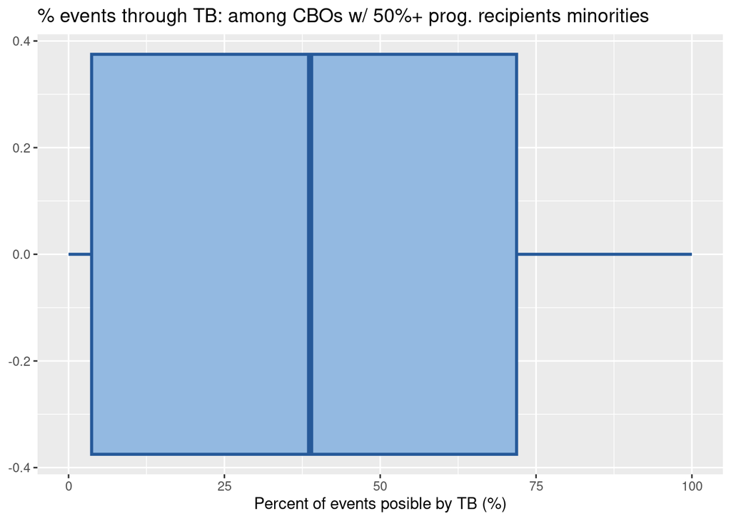

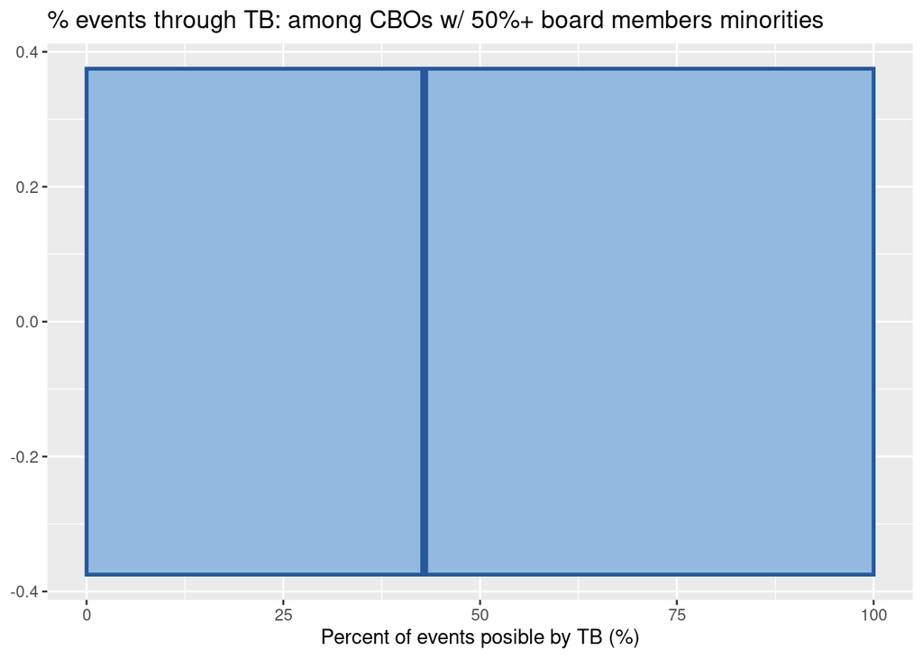

**Findings:**

- In an average year, the ToolBank helps to save money in buying, storing, tracking, and maintaining tools or equipments for the 45 respondents a sum value of $304, 700, among which purchasing tools and equipments cost our partner CBO the most with $226,300 (74.3%)
- In the past year, the ToolBank helps to save money in buying, storing, tracking, and maintaining tools or equipments for the 45 respondents a sum value of $113,720
- Half of the respondents reported that at least 35% of their events would have been impossible without the help of the ToolBank
- A total of 280 events would have been impossible if the ToolBank did not exist
- Half of the respondents reported that at least 150 of their constituents (volunteers, members, and event attendees) would have been negatively impacted without the help of the ToolBank
- A total of 58,790 constituents (volunteers, members, and event attendees) of our CBO partners would haven been negatively impacted without the help of the ToolBank

# Section 5: Community Impact of the Tool Bank

The following section summarizes the community impact of the ToolBank, as reported by survey respondents. This section aims to quantify the indirect ways that the ToolBank may impact CBOs and the community by reducing barriers and costs related to accessing tools and equipment. This section analyzes responded from the following survey questions:

- With the money you have saved on purchasing, storing, and maintaining tools and equipment through the TB, what have you been able to accomplish? -Without the TB, what would you no longer be able to fund?
- If you answered ‘staff’, how many positions would be impacted?
- If you answered ‘projects’, how many projects would be impacted?
- If other, please quantify the impact:
- Without the TB, which of the following are ways that your community events would be impacted? (check all that apply: Quantity, Quality, Diversity, Consistency)

| Table 5: Number and Percentage of Respondants Reporting Impacts of Funds Saved | Table 5: Number and Percentage of Respondants Reporting Impacts of Funds Saved # Respondents | Table 5: Number and Percentage of Respondants Reporting Impacts of Funds Saved % Respondents |
| --- | --- | --- |
| Accomplishments through money saved through TB |  |  |
| Hired more staff | 2 | 4.4% |
| Hosted additional projects/events | 27 | 60% |
| Other | 11 | 24.4% |
| Where funding would be cut if TB did not exist |  |  |
| Cut staff funding | 2 | 4.4% |
| Cut project funding | 26 | 57.8% |
| Other | 7 | 15.6% |

**Findings:**

- More than half of the respondents agree that they can host additional projects or event with the fundings the ToolBanks helped to save (60.0%) and would need to cut project fundings if the ToolBank did not exist (57.8%).
- Funding related to staff positions were less impacted by the ToolBank action.
- 24.4% respondents reported the fundings the ToolBank helps them to save make them able to achieve accomplishments other than staff positions and projects.
- 15.6% respondents reported that they need to cut fundings in items other than staff positions and projects if the ToolBank did not exist.

# Section 6: Fundraising Impact of the ToolBank

The following section aims to quantify the impact that the ToolBank may have on CBOs’ ability to host specific events, including fundraising. This section analyses the following survey questions:

- Which of the following types of events have TB tools and equipment helped your CBO complete?
- If you use the TB to support your fundraising events, in an average year, what have been the outcomes of these fundraising events?
- To your best estimate, what percent of your event expense budget was saved by using TB equipment at your event? Example: “We raised $20,000 at our annual fundraiser and hosted 150 people.”

The following plots address the question whether there is a relationship between money saved through the Toolbank and attitude towards the Toolbank

**Figures 23a-e: Money saved through TB (past year) by attitude towards TB**

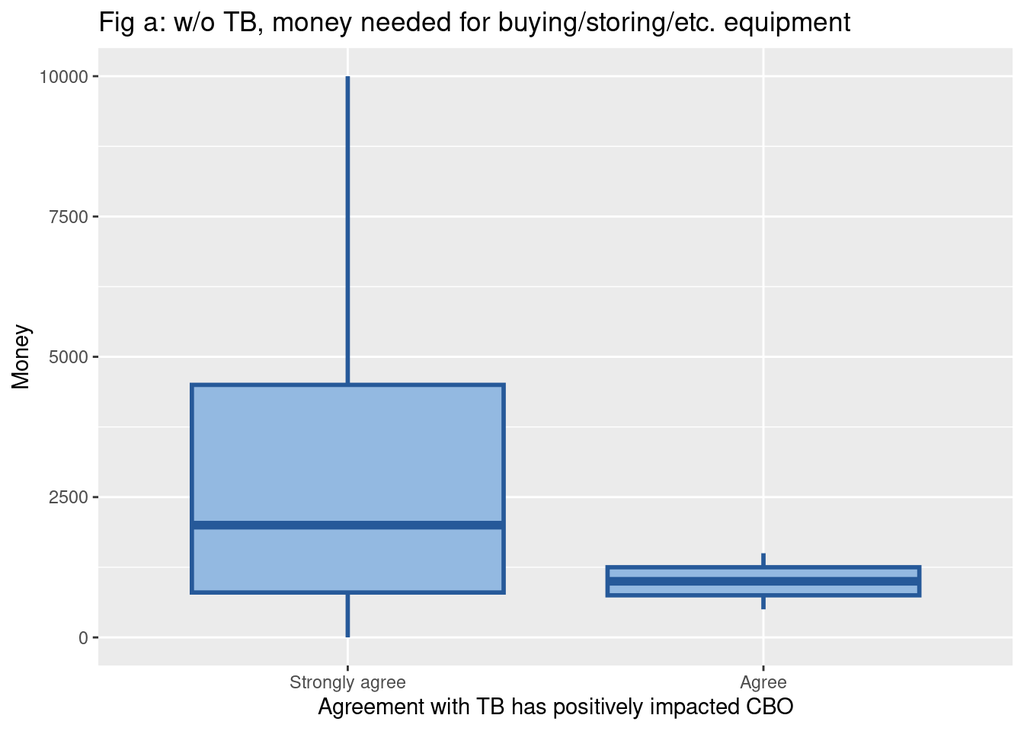

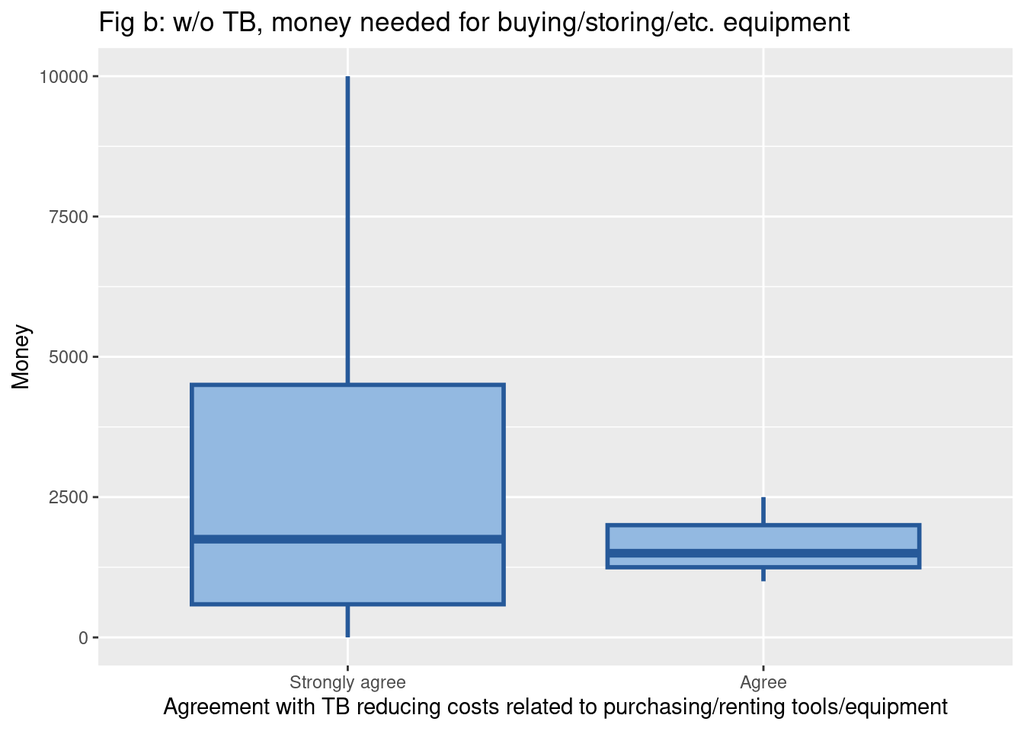

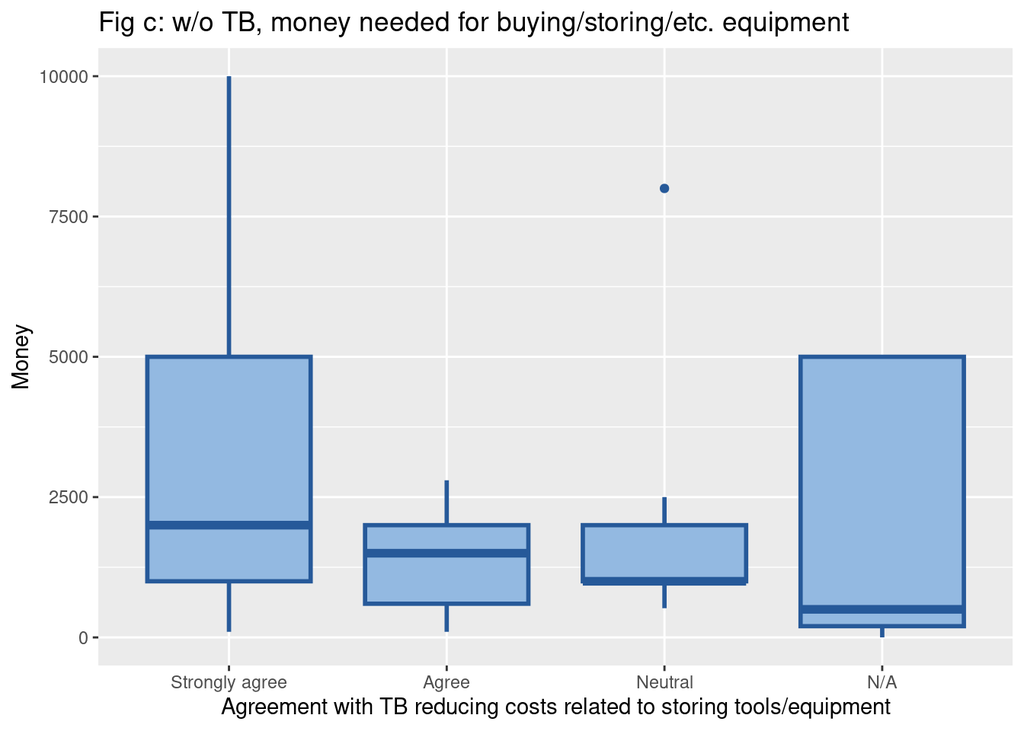

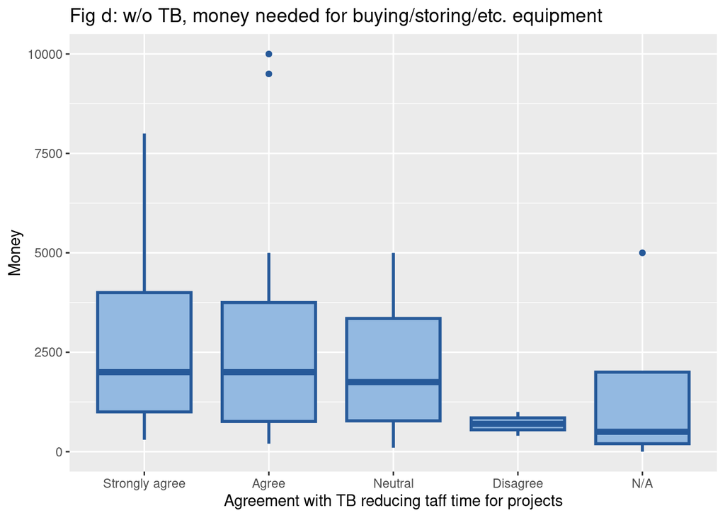

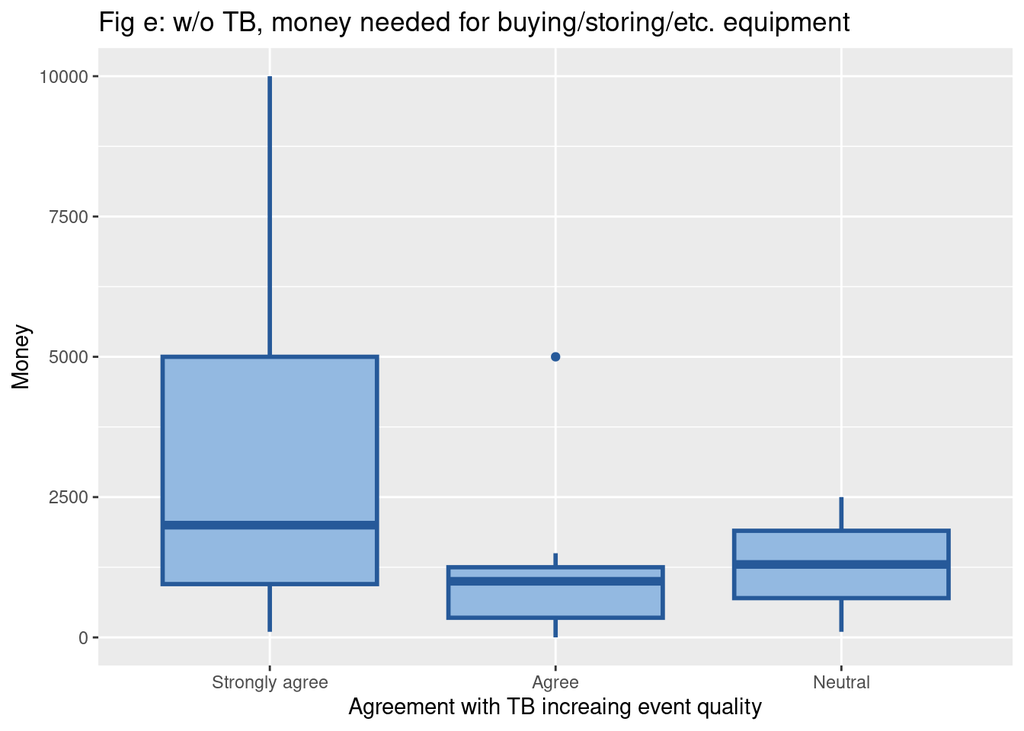

The following plots address the question of how savings vary by different Toolbank offerings